# Visualization Audit: Adult BMI by Income Group Across NHANES Cycles

## Question and data

**Descriptive question:** How did the unweighted mean BMI of adults (age 20+) in the NHANES classroom snapshot differ across income groups, cycle by cycle, from 1999-2000 to 2021-2023?

This is a descriptive comparison. It does not say *why* the groups differ and does not estimate national (population) values, because the survey weights, strata, and PSUs are not used.

The CSV path is relative to the repository root, which is the Quarto project execution directory (`execute-dir: project` in `_quarto.yml`).

```r
library(readr)
library(dplyr)
library(ggplot2)

nhanes <- read_csv(
  "examples/nhanes-equity/data/nhanes_equity_v6.csv",
  col_types = cols(
    Marital = col_character(),
    MaritalClean = col_character()
  ),
  show_col_types = FALSE
)

cycle_levels <- sort(unique(nhanes$Cycle))
cycle_levels
```

```
 [1] "1999-2000" "2001-2002" "2003-2004" "2005-2006" "2007-2008" "2009-2010"
 [7] "2011-2012" "2013-2014" "2015-2016" "2017-2018" "2021-2023"
```

## Step 1: Reproduce the flawed starter plot

This chunk reproduces the summary and plot from `flawed-plot-code.R` without its hard-coded Desktop path, so the audit can compare against it directly.

```r
endpoint_cycles <- c(cycle_levels[1], cycle_levels[length(cycle_levels)])

flawed_summary <- nhanes |>
  filter(!is.na(BMI), !is.na(IncomeGroup), Cycle %in% endpoint_cycles) |>
  group_by(Cycle, IncomeGroup) |>
  summarise(
    n = n(),
    min_age = min(Age),
    mean_bmi = mean(BMI),
    .groups = "drop"
  )

flawed_summary
```

```
# A tibble: 6 × 5
  Cycle     IncomeGroup            n min_age mean_bmi
  <chr>     <chr>              <int>   <dbl>    <dbl>
1 1999-2000 High Income (>3.5)  1804       2     25.3
2 1999-2000 Low Income (<1.3)   2831       2     24.3
3 1999-2000 Middle Income       2616       2     25.4
4 2021-2023 High Income (>3.5)  2665       2     27.2
5 2021-2023 Low Income (<1.3)   1902       2     27.0
6 2021-2023 Middle Income       2813       2     27.6
```

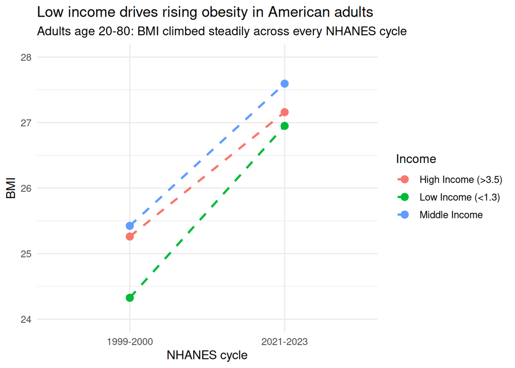

```r
ggplot(
  flawed_summary,
  aes(x = Cycle, y = mean_bmi, color = IncomeGroup, group = IncomeGroup)
) +
  geom_point(size = 3) +
  geom_line(linetype = "dashed", linewidth = 1) +
  scale_y_continuous(limits = c(24, 28)) +
  labs(
    title = "Low income drives rising obesity in American adults",
    subtitle = "Adults age 20-80: BMI climbed steadily across every NHANES cycle",
    x = "NHANES cycle",
    y = "BMI",
    color = "Income"
  ) +
  theme_minimal(base_size = 12)
```

What the summary table shows about the flawed plot:

- `min_age` is 2 in every group: the “Adults age 20-80” subtitle is false because no age filter was applied. Children have lower BMI and are over-represented in the low-income group, which is why low income has the *lowest* mean here, which contradicts the plot’s own title.
- Only two of the 11 cycles are used, so “climbed steadily across every NHANES cycle” can’t be checked from this plot. The dashed line implies a path the data never show.
- The y-axis is cut to 24-28 BMI units, which makes a gap of about 1 unit look large, and the plot shows no counts, uncertainty, or survey-design caveat.

## Step 2: First draft

My first draft fixed the age filter and used every cycle, but kept the default settings: alphabetical legend order (High, Low, Middle), raw `IncomeGroup` labels, no uncertainty, and an automatic y-axis.

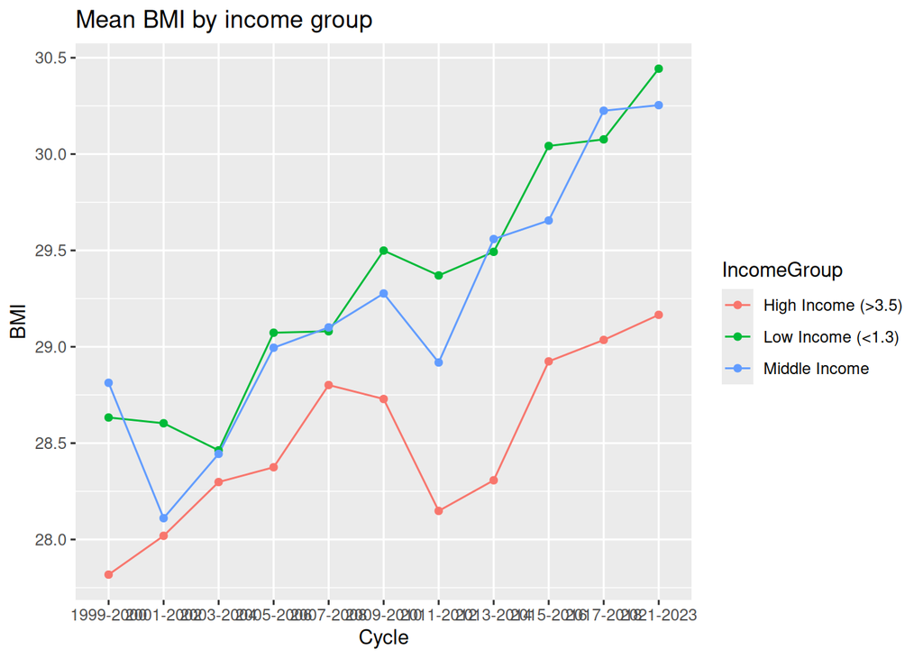

```r
adult_bmi <- nhanes |>
  filter(Age >= 20, !is.na(BMI), !is.na(IncomeGroup))

draft_summary <- adult_bmi |>
  group_by(Cycle, IncomeGroup) |>
  summarise(mean_bmi = mean(BMI), .groups = "drop")

ggplot(draft_summary, aes(Cycle, mean_bmi, color = IncomeGroup, group = IncomeGroup)) +
  geom_line() +
  geom_point() +
  labs(title = "Mean BMI by income group", y = "BMI")
```

Draft problems I found:

- The automatic y-axis covers only about 3 BMI units with no note, so small differences still look dramatic.
- Legend order (High, Low, Middle) doesn’t follow the income ordering, and “Middle Income” has no PIR cut-points in its label.
- Cycle labels overlap, and nothing shows the missing 2019-2020 cycle (a 2017-2018 to 2021-2023 jump is drawn as if it were one regular step).
- No group sizes or interval, so a reader can’t tell how stable each mean is.

## Step 3: Revised plot

Revisions:

1. **Population:** adults age 20+ only, matching the label. Rows with missing BMI or income group are excluded and the counts are reported.
2. **All cycles, honest spacing:** all 11 cycles are shown. The line is broken between 2017-2018 and 2021-2023 so it doesn’t hide the missing 2019-2020 cycle (NHANES fieldwork was cut short by COVID-19).
3. **Uncertainty:** each point carries a simple 95% interval (mean ± 1.96 SE). This is *unweighted* and ignores the survey design, so it describes the classroom sample only.
4. **Scale:** the y-axis is fixed at 25-32 BMI units, wider than the data, and the caption says so. A zero baseline would flatten the chart because BMI never comes near 0. The axis choice is stated instead of hidden.
5. **Labels and order:** income groups are ordered Low → Middle → High and labelled with PIR cut-points. The title says what is shown, not a cause.

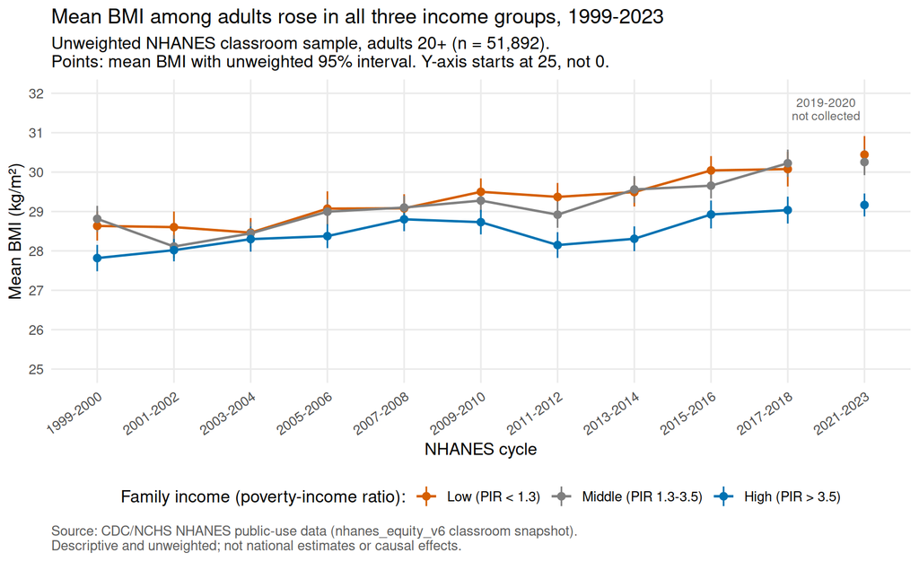

```r
income_labels <- c(
  "Low Income (<1.3)" = "Low (PIR < 1.3)",
  "Middle Income" = "Middle (PIR 1.3-3.5)",
  "High Income (>3.5)" = "High (PIR > 3.5)"
)

bmi_summary <- adult_bmi |>
  mutate(
    income = factor(income_labels[IncomeGroup], levels = income_labels),
    Cycle = factor(Cycle, levels = cycle_levels),
    # 2021-2023 follows the missing 2019-2020 cycle; break the line there
    segment = if_else(Cycle == "2021-2023", "after_gap", "before_gap")
  ) |>
  group_by(Cycle, segment, income) |>
  summarise(
    n = n(),
    mean_bmi = mean(BMI),
    se = sd(BMI) / sqrt(n),
    .groups = "drop"
  ) |>
  mutate(lower = mean_bmi - 1.96 * se, upper = mean_bmi + 1.96 * se)

n_adults <- nrow(adult_bmi)
n_excluded <- nhanes |>
  filter(Age >= 20, is.na(BMI) | is.na(IncomeGroup)) |>
  nrow()

income_colors <- c(
  "Low (PIR < 1.3)" = "#D55E00",
  "Middle (PIR 1.3-3.5)" = "#7F7F7F",
  "High (PIR > 3.5)" = "#0072B2"
)

corrected_plot <- ggplot(
  bmi_summary,
  aes(x = Cycle, y = mean_bmi, color = income)
) +
  geom_line(aes(group = interaction(income, segment)), linewidth = 0.8) +
  geom_pointrange(aes(ymin = lower, ymax = upper), size = 0.35) +
  annotate(
    "text", x = 10.5, y = 31.6, label = "2019-2020\nnot collected",
    size = 3, color = "grey40", lineheight = 0.9
  ) +
  scale_color_manual(values = income_colors) +
  scale_y_continuous(limits = c(25, 32), breaks = 25:32) +
  labs(
    title = "Mean BMI among adults rose in all three income groups, 1999-2023",
    subtitle = paste0(
      "Unweighted NHANES classroom sample, adults 20+ (n = ",
      format(n_adults, big.mark = ","),
      ").\nPoints: mean BMI with unweighted 95% interval. Y-axis starts at 25, not 0."
    ),
    x = "NHANES cycle",
    y = "Mean BMI (kg/m²)",
    color = "Family income (poverty-income ratio):",
    caption = paste(
      "Source: CDC/NCHS NHANES public-use data (nhanes_equity_v6 classroom snapshot).",
      "\nDescriptive and unweighted; not national estimates or causal effects.",
      sep = ""
    )
  ) +
  theme_minimal(base_size = 12) +
  theme(
    axis.text.x = element_text(angle = 35, hjust = 1),
    panel.grid.minor = element_blank(),
    legend.position = "bottom",
    plot.caption = element_text(hjust = 0, color = "grey35")
  )

corrected_plot
```

```r
ggsave(
  "assignments/assignment05-visualization/submission/corrected-plot.png",
  corrected_plot,
  width = 9, height = 5.5, dpi = 300, bg = "white"
)
```

Group sizes and summary values behind the plot:

```r
bmi_summary |>
  select(Cycle, income, n, mean_bmi, lower, upper) |>
  mutate(across(c(mean_bmi, lower, upper), \(x) round(x, 1))) |>
  knitr::kable(col.names = c("Cycle", "Income", "n", "Mean BMI", "95% lower", "95% upper"))
```

| Cycle | Income | n | Mean BMI | 95% lower | 95% upper |
| --- | --- | --- | --- | --- | --- |
| 1999-2000 | Low (PIR < 1.3) | 1146 | 28.6 | 28.3 | 29.0 |
| 1999-2000 | Middle (PIR 1.3-3.5) | 1434 | 28.8 | 28.5 | 29.1 |
| 1999-2000 | High (PIR > 3.5) | 1168 | 27.8 | 27.5 | 28.2 |
| 2001-2002 | Low (PIR < 1.3) | 1147 | 28.6 | 28.2 | 29.0 |
| 2001-2002 | Middle (PIR 1.3-3.5) | 1686 | 28.1 | 27.8 | 28.4 |
| 2001-2002 | High (PIR > 3.5) | 1538 | 28.0 | 27.7 | 28.3 |
| 2003-2004 | Low (PIR < 1.3) | 1264 | 28.5 | 28.1 | 28.8 |
| 2003-2004 | Middle (PIR 1.3-3.5) | 1753 | 28.4 | 28.2 | 28.7 |
| 2003-2004 | High (PIR > 3.5) | 1366 | 28.3 | 28.0 | 28.6 |
| 2005-2006 | Low (PIR < 1.3) | 1167 | 29.1 | 28.6 | 29.5 |
| 2005-2006 | Middle (PIR 1.3-3.5) | 1758 | 29.0 | 28.7 | 29.3 |
| 2005-2006 | High (PIR > 3.5) | 1536 | 28.4 | 28.1 | 28.7 |
| 2007-2008 | Low (PIR < 1.3) | 1552 | 29.1 | 28.7 | 29.4 |
| 2007-2008 | Middle (PIR 1.3-3.5) | 1982 | 29.1 | 28.8 | 29.4 |
| 2007-2008 | High (PIR > 3.5) | 1554 | 28.8 | 28.5 | 29.1 |
| 2009-2010 | Low (PIR < 1.3) | 1817 | 29.5 | 29.2 | 29.8 |
| 2009-2010 | Middle (PIR 1.3-3.5) | 2030 | 29.3 | 29.0 | 29.6 |
| 2009-2010 | High (PIR > 3.5) | 1562 | 28.7 | 28.4 | 29.0 |
| 2011-2012 | Low (PIR < 1.3) | 1724 | 29.4 | 29.0 | 29.7 |
| 2011-2012 | Middle (PIR 1.3-3.5) | 1630 | 28.9 | 28.6 | 29.3 |
| 2011-2012 | High (PIR > 3.5) | 1448 | 28.1 | 27.8 | 28.5 |
| 2013-2014 | Low (PIR < 1.3) | 1762 | 29.5 | 29.1 | 29.9 |
| 2013-2014 | Middle (PIR 1.3-3.5) | 1749 | 29.6 | 29.2 | 29.9 |
| 2013-2014 | High (PIR > 3.5) | 1586 | 28.3 | 28.0 | 28.6 |
| 2015-2016 | Low (PIR < 1.3) | 1568 | 30.0 | 29.7 | 30.4 |
| 2015-2016 | Middle (PIR 1.3-3.5) | 1925 | 29.7 | 29.3 | 30.0 |
| 2015-2016 | High (PIR > 3.5) | 1355 | 28.9 | 28.6 | 29.3 |
| 2017-2018 | Low (PIR < 1.3) | 1275 | 30.1 | 29.6 | 30.5 |
| 2017-2018 | Middle (PIR 1.3-3.5) | 1857 | 30.2 | 29.9 | 30.6 |
| 2017-2018 | High (PIR > 3.5) | 1359 | 29.0 | 28.7 | 29.4 |
| 2021-2023 | Low (PIR < 1.3) | 1141 | 30.4 | 30.0 | 30.9 |
| 2021-2023 | Middle (PIR 1.3-3.5) | 1965 | 30.3 | 29.9 | 30.6 |
| 2021-2023 | High (PIR > 3.5) | 2088 | 29.2 | 28.9 | 29.5 |

6,570 adults (age 20+) were excluded for missing BMI or income group. Missing income is not random (for example, it may be more common among people who decline to report income), so the remaining groups may not represent everyone in each cycle.

## Interpretation

In this unweighted classroom sample, mean adult BMI was higher in 2021-2023 than in 1999-2000 in every income group, at about 29-30 compared with about 28. From about 2005-2006 on, low- and middle-income adults usually had a slightly higher mean BMI than high-income adults, by roughly 0.5-1.3 BMI units. The low- and middle-income groups are hard to tell apart. These are descriptive differences in sample means. They do not show that income causes BMI, and they are not survey-weighted estimates for the U.S. population.

## Reproducing this file

From the repository root:

```bash
quarto render assignments/assignment05-visualization/submission/visualization-audit.qmd
```

Rendering re-creates `corrected-plot.png` in this folder through `ggsave()`.